# 独立2標本t検定（対応無しのt検定）

あなたの名前

2026-10-07

# 課題（対応無しのt検定 / 独立2標本t検定）

以下のデータは、76系統からなるイネの遺伝解析分離集団において、出穂後のイネの茎葉部（穂以外の地上部, shoot weight, SW）の乾物重を測定したものである。

- **Genotype A群**（24系統, table1.xlsx）: ジャポニカ型アレルをもつ系統群
- **Genotype B群**（52系統, table2.xlsx）: インディカ型アレルをもつ系統群
- **SW5**: 出穂後5日の茎葉重 (g/個体)
- **SW35**: 出穂後35日の茎葉重 (g/個体)
- **Decrease**: 出穂後の茎葉重の減少量（$SW5 - SW35$, 枯れ上がり度合い）

今回は、系統が互いに独立している（個体が別々で、サンプルサイズも24と52で異なる）2つのグループの間で平均値を比較する**「対応無しのt検定（Welchのt検定）」**を行います。

### 【本日の課題一覧】

- **課題１**：Genotype A（24系統）と Genotype B（52系統）の間で、出穂後35日の茎葉重（`SW35`）に差があるかどうかを検定しなさい（両側検定）。
- **課題２**：Genotype A と Genotype B の間で、茎葉重の減少量（`Decrease = SW5 - SW35`）に差があるかどうかを検定しなさい（両側検定）。
- **課題３**：茎葉重の減少量において、Genotype B群の平均が Genotype A群よりも大きいかどうかを検定しなさい（片側検定）。

## データの読み込みと準備

2つのExcelファイル（`table1.xlsx`, `table2.xlsx`）を読み込み、それぞれの群に遺伝子型ラベルを付与して結合します。

```r
library(readxl)

# Genotype A (24系統) の読み込み
table1 <- read_excel("table1.xlsx")
table1$Genotype <- "A"
table1$Decrease <- table1$SW5 - table1$SW35

# Genotype B (52系統) の読み込み
table2 <- read_excel("table2.xlsx")
table2$Genotype <- "B"
table2$Decrease <- table2$SW5 - table2$SW35

# 結合したデータフレームを作成
rice_data <- rbind(table1, table2)
rice_data$Genotype <- as.factor(rice_data$Genotype)

# データの先頭を確認
head(rice_data)
```

```
## # A tibble: 6 × 4
##     SW5  SW35 Genotype Decrease
##   <dbl> <dbl> <fct>       <dbl>
## 1  54.4  42.3 A           12.1
## 2  35.4  36.6 A           -1.20
## 3  41.6  38.9 A            2.71
## 4  41.0  49.0 A           -8.04
## 5  39.7  44.9 A           -5.18
## 6  66.8  56.9 A            9.95
```

```r
# 要約統計量の確認
summary(rice_data)
```

```
##       SW5             SW35       Genotype    Decrease
##  Min.   :21.27   Min.   :24.27   A:24     Min.   :-10.366
##  1st Qu.:40.53   1st Qu.:32.44   B:52     1st Qu.:  2.081
##  Median :49.69   Median :40.28            Median : 10.202
##  Mean   :51.33   Mean   :42.54            Mean   :  8.797
##  3rd Qu.:60.51   3rd Qu.:49.76            3rd Qu.: 14.948
##  Max.   :97.82   Max.   :89.23            Max.   : 30.321
```

## 課題1：出穂後35日の茎葉重 (SW35) の比較

### 1. グラフを描いてみる（箱ひげ図＋ドットプロット）

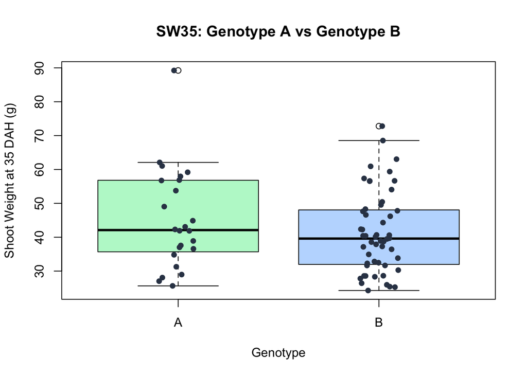

```r
# 箱ひげ図の描画
boxplot(SW35 ~ Genotype, data = rice_data,
        col = c("#bbf7d0", "#bfdbfe"),
        xlab = "Genotype", ylab = "Shoot Weight at 35 DAH (g)",
        main = "SW35: Genotype A vs Genotype B")

# ドットプロット（ジッター）を重ねる
stripchart(SW35 ~ Genotype, data = rice_data,
           vertical = TRUE, method = "jitter",
           pch = 16, col = "#334155", add = TRUE)
```

**【グラフから受ける印象】** - Genotype A（中央値 約42.1g, 平均 約45.2g）と Genotype B（中央値 約39.6g, 平均 約41.3g）の分布を比較すると、ややAの方が高い傾向に見えるものの、分布の重なりが非常に大きく、明らかな差があるとは断定しにくい印象を受ける。

### 2. 対応無しのt検定（Welchのt検定、両側検定）

```r
# Welchのt検定（Rでは var.equal = FALSE がデフォルト）
t.test(SW35 ~ Genotype, data = rice_data, alternative = "two.sided", conf.level = 0.95)
```

```
##
##  Welch Two Sample t-test
##
## data:  SW35 by Genotype
## t = 1.1491, df = 37.263, p-value = 0.2579
## alternative hypothesis: true difference in means between group A and group B is not equal to 0
## 95 percent confidence interval:
##  -3.016536 10.924416
## sample estimates:
## mean in group A mean in group B
##        45.24182        41.28788
```

### 3. 課題1の結果の解釈

- **仮説の設定**
  - **帰無仮説 ($H_0$)**: Genotype A と Genotype B のSW35の母平均に差はない（$\mu_A = \mu_B$）
  - **対立仮説 ($H_1$)**: Genotype A と Genotype B のSW35の母平均に差がある（$\mu_A \neq \mu_B$）
  - **有意水準**: $\alpha = 0.05$ (5%)、両側検定
- **検定結果**
  - 検定統計量: $t = 1.1491$
  - 自由度: $df = 37.263$
  - $p$値: $p = 0.2579$
  - 95%信頼区間: $[-3.017, 10.924]$（0を含む）
  - 標本平均: Genotype A = 45.24 g, Genotype B = 41.29 g
- **結論と解釈**
  - $p$値は $0.2579$ であり、有意水準 $0.05$ よりも大きい（$p > 0.05$）。
  - したがって、帰無仮説は棄却されない。
  - **結論**: Genotype A と Genotype B の間で、出穂後35日の茎葉重に統計学的に有意な差があるとはいえない。

## 課題2：茎葉重減少量 (Decrease = SW5 - SW35) の比較

出穂から登熟期にかけての茎葉重の「減少量（枯れ上がり度合い）」を比較します。

### 1. グラフを描いてみる

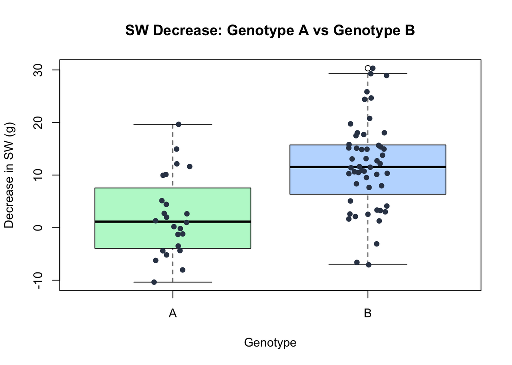

```r
# 箱ひげ図
boxplot(Decrease ~ Genotype, data = rice_data,
        col = c("#bbf7d0", "#bfdbfe"),
        xlab = "Genotype", ylab = "Decrease in SW (g)",
        main = "SW Decrease: Genotype A vs Genotype B")

# ドットプロット
stripchart(Decrease ~ Genotype, data = rice_data,
           vertical = TRUE, method = "jitter",
           pch = 16, col = "#334155", add = TRUE)
```

**【グラフから受ける印象】** - Genotype A の減少量は 0 付近に集中している（平均 約2.21g）のに対し、Genotype B の減少量は明らかに全体が高くシフトしている（平均 約11.84g）。両群の間で分布に明確な差があり、Genotype Bの方が明らかに減少量が大きい印象を受ける。

### 2. 対応無しのt検定（Welchのt検定、両側検定）

```r
# Welchのt検定
t.test(Decrease ~ Genotype, data = rice_data, alternative = "two.sided", conf.level = 0.95)
```

```
##
##  Welch Two Sample t-test
##
## data:  Decrease by Genotype
## t = -4.9457, df = 49.342, p-value = 9.193e-06
## alternative hypothesis: true difference in means between group A and group B is not equal to 0
## 95 percent confidence interval:
##  -13.540005  -5.716831
## sample estimates:
## mean in group A mean in group B
##        2.209492       11.837910
```

### 3. 課題2の結果の解釈

- **仮説の設定**
  - **帰無仮説 ($H_0$)**: Genotype A と Genotype B の茎葉重減少量の母平均に差はない（$\mu_A = \mu_B$）
  - **対立仮説 ($H_1$)**: Genotype A と Genotype B の茎葉重減少量の母平均に差がある（$\mu_A \neq \mu_B$）
  - **有意水準**: $\alpha = 0.05$ (5%)、両側検定
- **検定結果**
  - 検定統計量: $t = -4.9457$
  - 自由度: $df = 49.342$
  - $p$値: $p = 9.193 \times 10^{-6}$ ($p < 0.001$)
  - 95%信頼区間: $[-13.540, -5.717]$（0を含まない）
  - 標本平均: Genotype A = 2.21 g, Genotype B = 11.84 g
- **結論と解釈**
  - $p$値は $9.193 \times 10^{-6}$ であり、有意水準 $0.05$（さらには $0.001$）よりも極めて小さい（$p < 0.001$）。
  - したがって、帰無仮説は棄却され、対立仮説が採択される。
  - **結論**: Genotype A と Genotype B の間で、茎葉重の減少量に統計学的に極めて有意な差が認められる。

## 課題3：茎葉重減少量の片側検定

Genotype B の減少量が Genotype A よりも大きいかどうかを片側検定で検証します。

```r
# 片側検定（Genotype A の平均 < Genotype B の平均、すなわち A - B < 0 なので alternative = "less"）
t.test(Decrease ~ Genotype, data = rice_data, alternative = "less", conf.level = 0.95)
```

```
##
##  Welch Two Sample t-test
##
## data:  Decrease by Genotype
## t = -4.9457, df = 49.342, p-value = 4.596e-06
## alternative hypothesis: true difference in means between group A and group B is less than 0
## 95 percent confidence interval:
##       -Inf -6.364918
## sample estimates:
## mean in group A mean in group B
##        2.209492       11.837910
```

## 全体の考察（対応のあるt検定と対応無しのt検定の統合理解）

1. **対応ありと対応無しの使い分け**:
   - 前回の演習では、同一系統内における出穂後5日（SW5）と35日（SW35）の前後比較を「対応のあるt検定」で解析した。
   - 今回は、別個体・別系統からなる「Genotype A群（24系統）」と「Genotype B群（52系統）」という独立した2群の差を「対応無しのt検定」で解析した。
2. **生物学的意義**:
   - SW35単独の比較では、系統間の個体差（ばらつき）が大きいため有意差は検出されなかった（$p = 0.2579$）。
   - しかし、各系統の出穂時の茎葉重を基準とした減少量（`SW5 - SW35`）を評価すると、両群間に極めて顕著な有意差が認められた（$p = 9.193 \times 10^{-6}$）。
   - これは、Genotype A（ジャポニカ型アレル）は出穂後も茎葉部が枯れ上がりにくい「ステイグリーン（stay-green）」特性をもち、Genotype B（インディカ型アレル）は穂への栄養再転流や葉の老化が急速に進んで「枯れ上がる」表現型を決定づける遺伝的要因（QTL）であることを強力に裏付けている。